# diffudist

[figure not shown]

[figure not shown]

## Overview

The `diffudist` package provides several functions for evaluating the diffusion distance between nodes of a complex network.

## Installation

```r
# Or the development version from GitHub
# install.packages("devtools")
devtools::install_github("gbertagnolli/diffudist")
```

## Usage

Additionally to `diffudist` you will also need the `igraph` package, because the main arguments of the functions in `diffudist` are networks as `igraph` objects.

```r
library(diffudist)
library(igraph)
igraph_options(
  vertex.frame.color = "white",
  vertex.color = "#00B4A6",
  label.family = "sans-serif")
```

### Examples

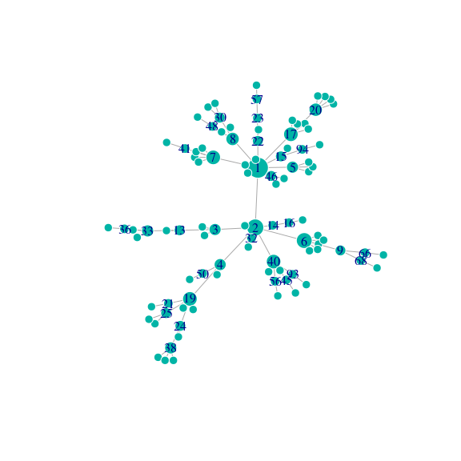

```r
N <- 100
g <- sample_pa(N, directed = FALSE)
deg_g <- degree(g)
vertex_labels <- 1:N
vertex_labels[which(deg_g < quantile(deg_g, .75))] <- NA
plot(g, vertex.label = vertex_labels, vertex.size = 6 + 10 * (deg_g - min(deg_g)) / max(deg_g))
```

```r
D <- get_DDM(g, tau = 2, type = "Normalized Laplacian", verbose = FALSE)
MERW_Pt <- get_diffu_Pt(g, tau = 2, type = "MERW")
```

```
#> Unweighted network.
#> Evaluating the MERW Normalized Laplacian matrix
```

The probability transition matrix returned from `get_diffusion_probability_matrix` (or its shortened version `get_diffu_Pt`) is the matrix *e*<sup>− *τ**L*<sub>rw</sub></sup>. The diffusion dynamics is controlled by the specific Laplacian matrix *L*<sub>rw</sub> = *I* − *T*<sub>rw</sub>, where *T*<sub>rw</sub> is the jump matrix of the discrete-time random walk corresponding to our continuous-time dynamics.

Let us check that `MERW_Pt` is an actual stochastic (transition) matrix, i.e., that its rows are probability vectors

```r
if (sum(MERW_Pt)  - N > 1e-6) {
  print("MERW_Pt is not a stochastic matrix")
} else {
  print("MERW_Pt is a stochastic matrix")
}
```

```
#> [1] "MERW_Pt is a stochastic matrix"
```

Compute diffusion distances from the Probability matrix `MERW_Pt` as follows:

```r
if (requireNamespace("parallelDist", quietly = TRUE)) {
  # parallel dist
  D_MERW <- as.matrix(parallelDist::parDist(MERW_Pt))
} else {
  # dist
  D_MERW <- as.matrix(stats::dist(MERW_Pt))
}
```

And finally plot the distance matrices (requires `ggplt2`)

```r
if (requireNamespace("tidyverse", quietly = TRUE)) {
  library(tidyverse)
  plot_ddm <- function(ddm, clustering = FALSE) {
    N <- nrow(ddm)
    as_tibble(ddm) %>%
      add_column("from" = 1:N, .before = 1) %>%
      gather(key = to, value = value, -from, factor_key = TRUE) %>%
      mutate(
        "to" = as.numeric(gsub(pattern = "V", replacement = "", x = to)),
        "value" = as.numeric(value)
      ) %>%
      ggplot(mapping = aes(x = to, y = from, fill = value)) +
        geom_tile() +
        coord_equal() +
        labs(x = "", y = "") +
        scale_y_reverse(breaks = seq(N, 1, -10), expand = c(0, 0)) +
        scale_x_continuous(position = "top", breaks = seq(1, N, 10), expand = c(0, 0)) +
        scale_fill_distiller(palette = "Spectral", limits = c(0, ceiling(max(ddm)))) +
        guides(fill = guide_colourbar(barwidth = 1, barheight = 10, nbin = 100)) +
        theme_minimal() +
        theme(
          panel.grid.minor = element_blank(),
          panel.grid.major = element_blank(),
          axis.text.x = element_blank(),
          axis.text.y = element_blank()) -> pl
      return(pl)
  }
} else {
  plot_ddm <- function(ddm, clustering = TRUE) {
    gplots::heatmap.2(D, distfun = as.dist)
  }
}
```

##### Plot with hierarchical clustering

And finally plot the distance matrices (requires `ggplot2` and `ggdengro`)

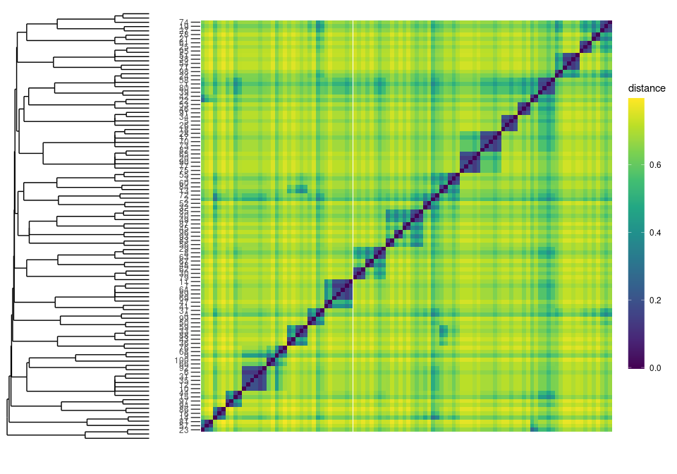

```r
plot_distance_matrix(D)
```

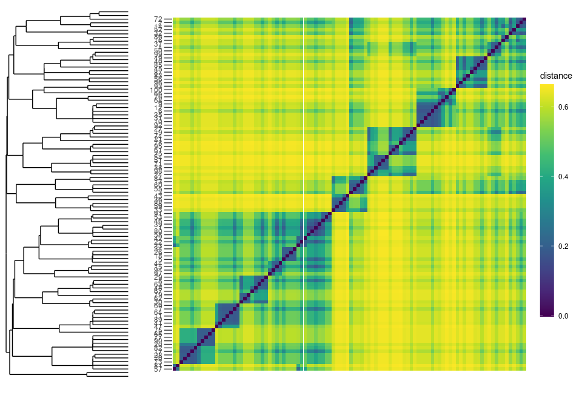

```r
plot_distance_matrix(D_MERW)
```

## References

Bertagnolli, G., & De Domenico, M. (2021). *Diffusion geometry of multiplex and interdependent systems*. Physical Review E, 103(4), 042301. [DOI: 10.1103/PhysRevE.103.042301](https://doi.org/10.1103/PhysRevE.103.042301), [arXiv: 2006.13032](https://arxiv.org/abs/2006.13032), [my-website](https://gbertagnolli.github.io/publication/ml-diffusion/).